# CourseProject_#1

Kim

2017.7.27

This is for Coursera Course Project 1.

## Before the Instructions

1.First, load the data.

```r
data <- read.csv("activity.csv")
str(data)
```

```
## 'data.frame':    17568 obs. of  3 variables:
##  $ steps   : int  NA NA NA NA NA NA NA NA NA NA ...
##  $ date    : Factor w/ 61 levels "2012-10-01","2012-10-02",..: 1 1 1 1 1 1 1 1 1 1 ...
##  $ interval: int  0 5 10 15 20 25 30 35 40 45 ...
```

2. Processing for ‘date’

```r
data$date <- as.Date(data$date, format = "%Y-%m-%d")
str(data)
```

```
## 'data.frame':    17568 obs. of  3 variables:
##  $ steps   : int  NA NA NA NA NA NA NA NA NA NA ...
##  $ date    : Date, format: "2012-10-01" "2012-10-01" ...
##  $ interval: int  0 5 10 15 20 25 30 35 40 45 ...
```

And then follow the instructions.

## What is mean total number of steps taken per day ?

1. The total number of steps taken per day.

```r
sum <- with(data, tapply(steps,date,sum,na.rm=TRUE))
sum
```

```
## 2012-10-01 2012-10-02 2012-10-03 2012-10-04 2012-10-05 2012-10-06
##          0        126      11352      12116      13294      15420
## 2012-10-07 2012-10-08 2012-10-09 2012-10-10 2012-10-11 2012-10-12
##      11015          0      12811       9900      10304      17382
## 2012-10-13 2012-10-14 2012-10-15 2012-10-16 2012-10-17 2012-10-18
##      12426      15098      10139      15084      13452      10056
## 2012-10-19 2012-10-20 2012-10-21 2012-10-22 2012-10-23 2012-10-24
##      11829      10395       8821      13460       8918       8355
## 2012-10-25 2012-10-26 2012-10-27 2012-10-28 2012-10-29 2012-10-30
##       2492       6778      10119      11458       5018       9819
## 2012-10-31 2012-11-01 2012-11-02 2012-11-03 2012-11-04 2012-11-05
##      15414          0      10600      10571          0      10439
## 2012-11-06 2012-11-07 2012-11-08 2012-11-09 2012-11-10 2012-11-11
##       8334      12883       3219          0          0      12608
## 2012-11-12 2012-11-13 2012-11-14 2012-11-15 2012-11-16 2012-11-17
##      10765       7336          0         41       5441      14339
## 2012-11-18 2012-11-19 2012-11-20 2012-11-21 2012-11-22 2012-11-23
##      15110       8841       4472      12787      20427      21194
## 2012-11-24 2012-11-25 2012-11-26 2012-11-27 2012-11-28 2012-11-29
##      14478      11834      11162      13646      10183       7047
## 2012-11-30
##          0
```

2. Make a histogram of the total number of steps taken each day.
3. Calculate and report the mean and median of the total number of steps taken per day

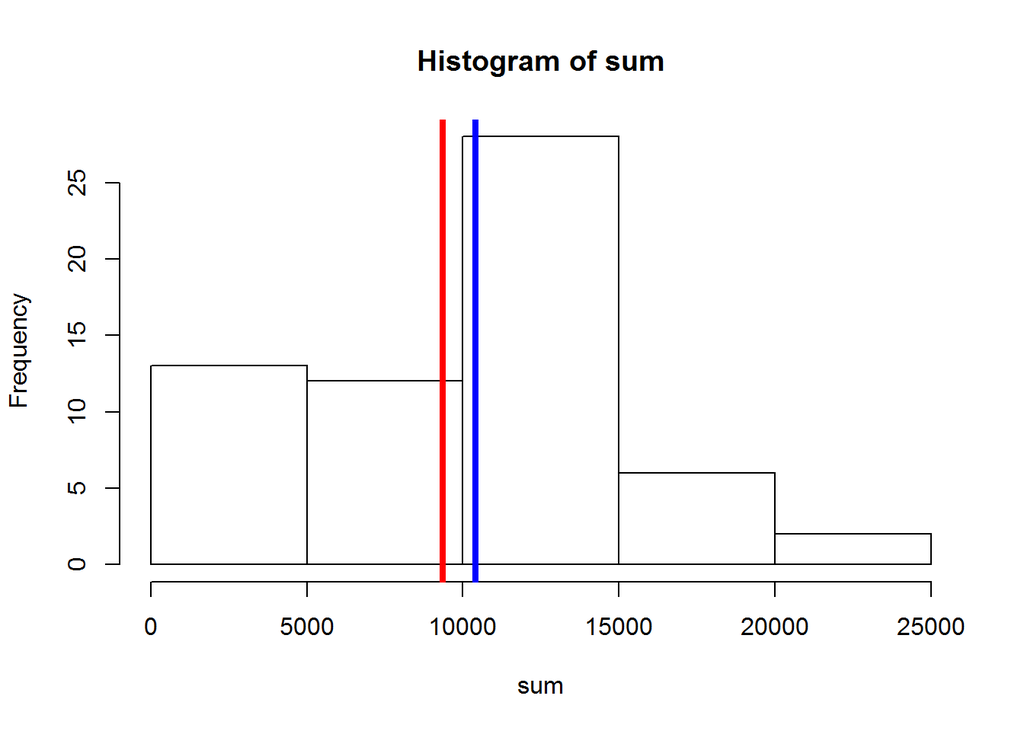

[output not shown]

[output not shown]

```r
hist(sum)
abline(v = mean(sum), col = "red", lwd = 4)
abline(v = median(sum), col = "blue", lwd = 4)
```

On the figure above, there are two vertical lines which stand for mean and median. Red line is for mean of sum, and blue line is for median of sum.DF

## What is the average daily activity pattern ?

1. Make a time series plot on every interval.

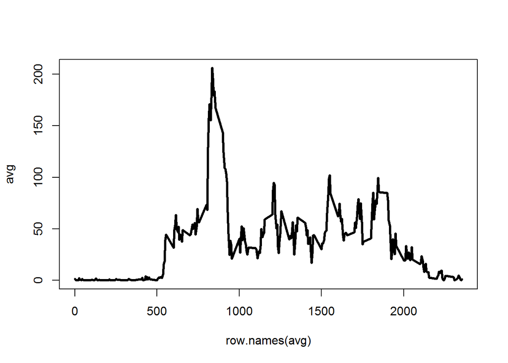

```r
avg <- with(data,tapply(steps,interval,mean,na.rm=TRUE))
plot(row.names(avg),avg,type = 'l', lwd = 3)
```

2. Which 5-minute interval on average across all the days in the dataset, contains the maximum numbers of step?

```r
cat("Time interval which has the maximum numbers of step : ", row.names(avg)[which.max(avg)])
```

```
## Time interval which has the maximum numbers of step :  835
```

# What is ‘imputation’ ?

In statistics, imputation is the process of replacing missing data with substituted values. - Wikipedia

1. Calculate and report the total number of missing values in the dataset

```r
cat("Total number of NAs: ", sum(sapply(data$steps, function(x) sum(length(which(is.na(x)))))))
```

```
## Total number of NAs:  2304
```

2. Devise a strategy for filling in all of the missing values in the dataset. (could use the mean / median for that day, or the mean for that 5-minute interval,etc.)

   -> I will impute the data with the mean for that 5-minute interval.
3. Create a new dataset that is equal to the original dataset but with the missing data filled in.

```r
avg_by_interval <- with(data,tapply(steps,interval,mean,na.rm =TRUE))
num_of_rows <- dim(data)[1]  # the num of data.
ch <- data[c(1,3)]
ch_date <- data[c(2)]
s <- sapply(ch$steps, function(x) length(which(is.na(x))))
names <- as.integer(names(avg_by_interval))

z <- as.data.frame(avg_by_interval)
z <- cbind(names,z)

 # 's' stands for indicating which one is 'NAs'
 # So , 's[i] == 1' means that we need to process on it.

for(i in 1:num_of_rows){

  if(s[i] == 1)
  {
    ch[i,1] <- subset(z$avg_by_interval , z$names == ch[i,2])
  }

}


 # In 'ch' , steps & interval are configurated.
 # Merging date and 'ch'


mrg <- cbind(ch,ch_date)  # Mrg indicates the new dataset with the missing data
                          # filled in.
```

4. Make a histogram based on the new dataset.(mrg) What is the impact of imputing missing data on the estimates of the total daily number of steps?

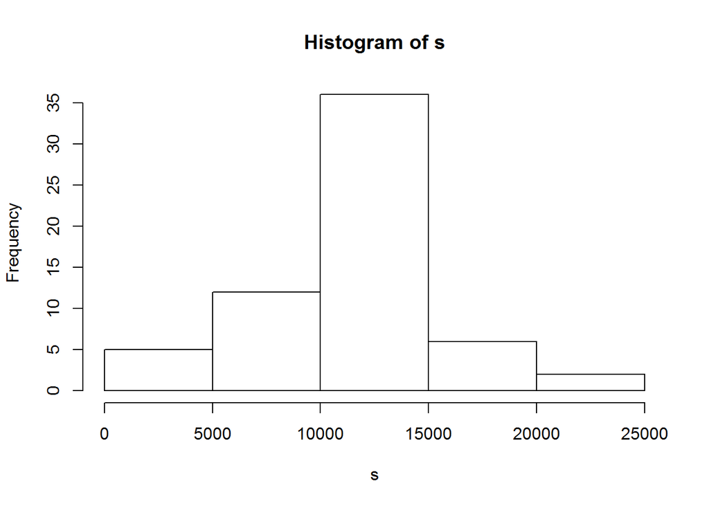

```r
# new dataset : mrg
s <- with(mrg, tapply(steps,date,sum,na.rm=TRUE))
hist(s)
```

```r
cat("Mean: ", mean(s))
```

```
## Mean:  10766.19
```

```r
cat("Median: ", median(s))
```

```
## Median:  10766.19
```

As shown above, histogram is different from first one. By imputing the data, we could get more ‘gaussian-likely’ form. Because we got more data by substituting NAs with real values. The more we get N, density will go to the normal based on statistical reason.

Also, by imputing, I could extract same values with mean and median.

## Are there differences in activity patterns between weekdays and weekends?

```r
mrg$days <- weekdays(mrg$date) # Adding new column indicating days.
head(mrg)
```

```
##       steps interval       date   days
## 1 1.7169811        0 2012-10-01 월요일
## 2 0.3396226        5 2012-10-01 월요일
## 3 0.1320755       10 2012-10-01 월요일
## 4 0.1509434       15 2012-10-01 월요일
## 5 0.0754717       20 2012-10-01 월요일
## 6 2.0943396       25 2012-10-01 월요일
```

Make 2 dataset. One for weekdays and the other for weekends.

1. Create a new factor variable in the dataset with two levels- “weekday” and “weekend” indicating whether a given date is a weekday or weekend.  
   NOTICE: MY R OUTPUT ENVIRONMENT IS BASED ON ‘KOREAN’. I COULDN’T CHANGE MY ENVIRIONMENT ALTHOUGH I TRIED SEVERAL TRIALS.

   토요일: Saturday 일요일: Sunday

```r
w <- factor()

for(i in 1:dim(mrg)[1]){

if(mrg[i,]$days =="토요일" | mrg[i,]$days=="일요일"){
  w <- rbind(w,"weekend")
}else{
  w <- rbind(w,"weekday")
}
}

mrg <- cbind(mrg,w) # mrg contains 'weekdays' column !
```

2. Make panel plot containing a time series plot of the 5-minute interval. I’ll use ‘aggregate’ function.

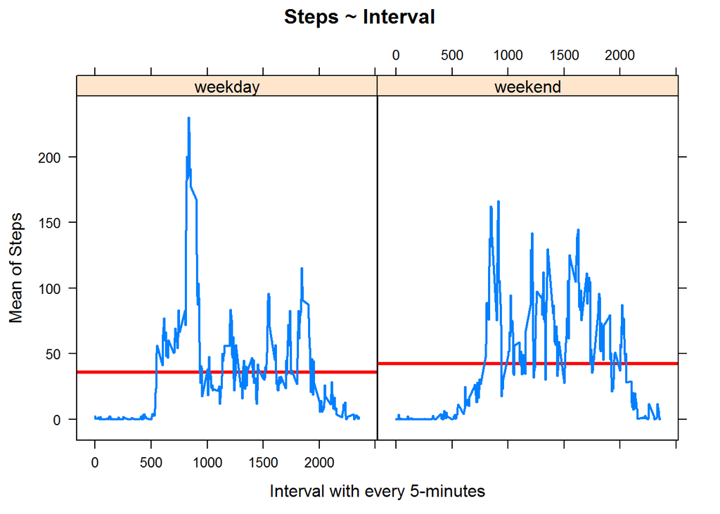

```r
# Using aggregate function

avg_by_sw <- aggregate(steps ~ interval + w , data = mrg , mean)
library(lattice)

xyplot(steps~ interval | w, data = avg_by_sw , type = 'l',  lwd = 2, layout = c(2,1), xlab = "Interval with every 5-minutes", ylab ="Mean of Steps", main =  "Steps ~ Interval", panel = function(x,y,...){

panel.abline(h = mean(y), col = "red", lwd = 3)
panel.xyplot(x,y,...)

})
```

The red horizontal line indicates mean of each steps of given time interval. In general,as shown above, people walk more on weekends.